# Payday Loans and Customer Service

T. Morrison

In this script for the CFPB consumer complaint data, I am going to look at a somewhat contentious financial product that is receiving some extra scrutiny, according to an [NPR Freakonomics Radio show](http://freakonomics.com/podcast/payday-loans/) I heard recently: **payday loans**.

First, loading up the packages and getting the data from the SQL file provided by Kaggle. I’ll be using `RSQLite` to query the SQLite database.

```r
library(RSQLite)
library(DBI)
library(ggplot2)
library(Cairo)
library(data.table)
library(ggthemes)

con <- dbConnect(SQLite(), "C:/sqlite/kaggle1.sqlite")
x<- data.table(dbReadTable(con, "consumer_complaints"))
```

The dataset has over 500,000 complaints in it, but how many are for payday loans compared to other financial products?

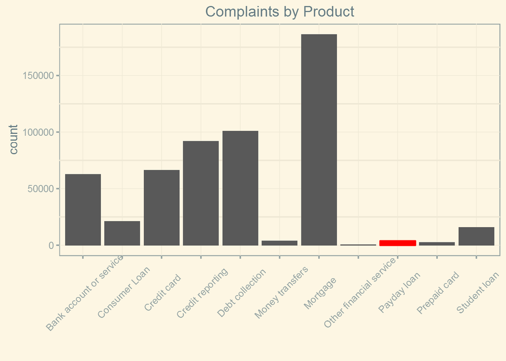

```r
ggplot(x, aes(x=product)) +
  geom_bar() +
  geom_bar(data=x[product=="Payday loan"], aes(product), color= "red", fill="red") +
  ggtitle("Complaints by Product") + xlab("") +
  theme_solarized() +
  theme(axis.text.x=element_text(angle=45, vjust=.6))
```

```r
x[, .N, by=product][order(-N)]
```

```
##                     product      N
##  1:                Mortgage 186475
##  2:         Debt collection 101052
##  3:        Credit reporting  91854
##  4:             Credit card  66468
##  5: Bank account or service  62563
##  6:           Consumer Loan  20990
##  7:            Student loan  15839
##  8:             Payday loan   3877
##  9:         Money transfers   3812
## 10:            Prepaid card   2470
## 11: Other financial service    557
```

```r
pd <- x[product=="Payday loan"]
```

What issues do people have with payday loans?

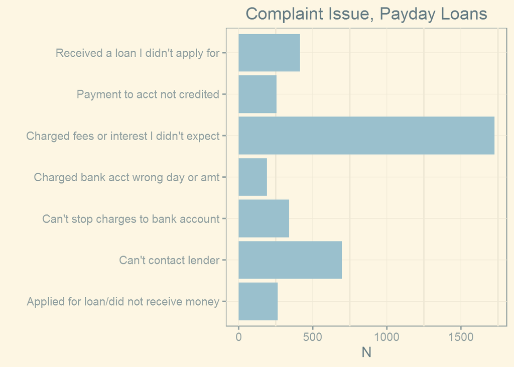

```r
ggplot(pd, aes(x=issue, fill=)) +
  geom_bar(fill="lightblue3") +
  coord_flip() +
  ggtitle("Complaint Issue, Payday Loans") + xlab("") + ylab("N") +
  theme_solarized(base_size = 14)
```

As you might expect, the biggest complaint related to payday loans is being charged unexpected fees or interest. Critics of payday loans point to the 300 and 400 percent interest rates that borrowers get sucked into when they cannot repay their loans quickly enough.

What does the company have to say when consumers complain about unexpected fees or interest? Using `company_public_response` we can see.

```r
pd[issue=="Charged fees or interest I didn't expect", .N, by=company_public_response][order(-N)]
```

```
##                                                                                                     company_public_response
##  1:                                                                                                                      NA
##  2:                                                Company believes it acted appropriately as authorized by contract or law
##  3:                                                                        Company chooses not to provide a public response
##  4:                                                                   Company disputes the facts presented in the complaint
##  5: Company believes complaint caused principally by actions of third party outside the control or direction of the company
##  6:                                                      Company believes the complaint is the result of a misunderstanding
##  7:                         Company has responded to the consumer and the CFPB and chooses not to provide a public response
##  8:                                                           Company believes complaint is the result of an isolated error
##  9:                          Company believes complaint represents an opportunity for improvement to better serve consumers
## 10:                                                              Company can't verify or dispute the facts in the complaint
##        N
##  1: 1478
##  2:  128
##  3:   44
##  4:   32
##  5:   18
##  6:    8
##  7:    7
##  8:    3
##  9:    3
## 10:    3
```

If you can follow the annoyingly wrapped output, you’ll see that in the vast majority of cases, the company didn’t provide a public response. But when they did, 128 out of 246 times they believed they were acting appropriately according to the contract or law (aka you’re screwed).

And what did the companies say to these consumers who complained about unexpected fees or interest?

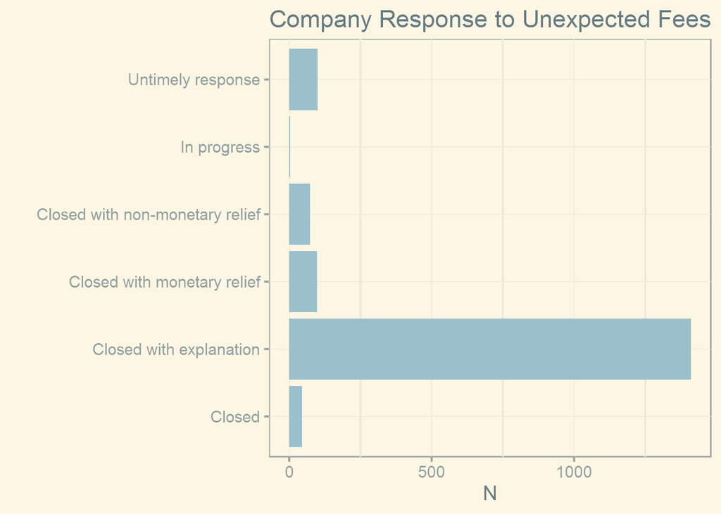

```r
ggplot(pd[issue=="Charged fees or interest I didn't expect"], aes(x=company_response_to_consumer)) +
  geom_bar(fill="lightblue3") +
  coord_flip() +
  ggtitle("Company Response to Unexpected Fees") + xlab("") + ylab("N") +
  theme_solarized(base_size = 14)
```

I’m guessing that explanation did not mean too much to the consumers here.

### Personal Stories

We can get a personal look at some of these complaints through the `consumer_complaint_narrative`, a variable containing the text of the consumer’s complaint. Unfortunately this variable is only provided if the consumer explicitly gave consent, and many did not. There are still a good amount though and I will be looking for some keywords within them.

#### Lies, damn lies, and statistics

First, did many people feel like they had been lied to or misled regarding their payday loan?

Let’s look specifically at the following keywords:

- ‘lie’ (includes ‘lied’ but not words like ‘applied’)
- ‘mislead’
- ‘misled’
- ‘lying’
- ‘steal’
- ‘stole’

```r
pd2 <- pd[!is.na(pd$consumer_complaint_narrative)] #rows that are not NAs

match <- c(" lie", "mislead", " lying", " steal", " stole", "misled")
pdLies <- grepl(paste(match, collapse="|"), pd2$consumer_complaint_narrative)
summary(pdLies)
```

```
##    Mode   FALSE    TRUE    NA's
## logical     692      34       0
```

Only 34 of 726 consumers used those keywords in their complaint.

How does this compare to the mortgage complaints?

```r
mo <- x[product=="Mortgage"]
mo2 <- mo[!is.na(mo$consumer_complaint_narrative)]

moLies <- grepl(paste(match, collapse="|"), mo2$consumer_complaint_narrative)
summary(moLies)
```

```
##    Mode   FALSE    TRUE    NA's
## logical   13177    1742       0
```

#### Customer service

How do these consumers think of the customer service of their financial institutions? Let’s cue up the search for some new keywords. I’ll start by looking by `product` in a more comprehensive way than above, by looking across every category at once.

I’ll use the keywords:

- ‘rude’
- ‘insult’
- ‘disrespectful’
- ‘unhelpful’
- ‘unfriendly’

With the code below, I have found the percentage of complaint narratives containing the above keywords by `product`.

```r
cs <- c(" rude", "insult", "disrespectful", "unhelpful", "unfriendly") #keywords

x2 <- x[!is.na(x$consumer_complaint_narrative)]  #every row in original dataset containing a narrative

x2[, CS := grepl(paste(cs, collapse="|"),    #new logical column `CS`; TRUE for narratives containing keywords
                 x2$consumer_complaint_narrative)]

x3 <- x2[, .N, by=.(product, CS)][order(product,CS)] #count number of T/F in `CS`  by `product` and reorder

x3[, Percent := (N/(N+shift(N))), by=product] #calculate (T)/(T + F) to get percentage of complaint narratives
head(x3, n=5)                                 #that contained the keywords, by `product`
```

```
##                    product    CS    N    Percent
## 1: Bank account or service FALSE 5478         NA
## 2: Bank account or service  TRUE  233 0.04079846
## 3:           Consumer Loan FALSE 3508         NA
## 4:           Consumer Loan  TRUE  170 0.04622077
## 5:             Credit card FALSE 7685         NA
```

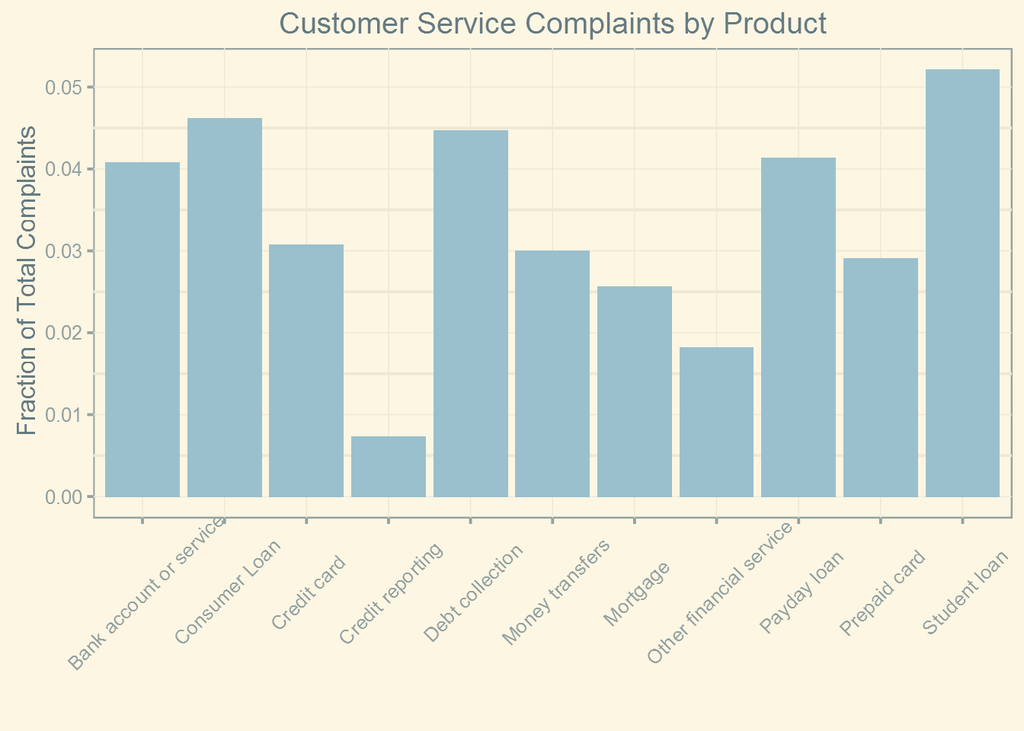

```r
ggplot(x3[!is.na(x3$Percent)], aes(x=product, y= Percent)) +
  geom_bar(stat="identity", fill="lightblue3") +
  ggtitle("Customer Service Complaints by Product") + xlab("") + ylab("Fraction of Total Complaints") +
  theme_solarized() +
  theme(axis.text.x=element_text(angle=45, vjust=.6))
```

Of all the products, consumers complaining about student loans and consumer loans used language indicating displeasure with their interactions with the company at the highest rates, above even debt collection and payday loans.

I will continue with this analysis, perhaps looking at the companies that have the most complaints against them to see how their customer service stacks up. Until next time.